# The Global Recovery Gap

Life Expectancy Before, During, and After COVID-19

Mohd Afwan Shaikh

# Introduction

For my first dataset, I selected life expectancy data from the World Bank. I explored how life expectancy changed across different countries before, during, and after the COVID-19 pandemic. My main goal was to understand whether countries recovered at the same rate or whether some continued to experience lower life expectancy.

# Data Source

The dataset comes from the World Bank’s World Development Indicators database.

- **Dataset:** Life expectancy at birth, total (years)
- **Indicator:** SP.DYN.LE00.IN
- **Source:** [World Bank Life Expectancy Data](https://data.worldbank.org/indicator/SP.DYN.LE00.IN)

The original dataset contains countries, regional aggregates, and separate columns for each year. I also used country metadata to identify regions and income groups.

# Research Question

How did life expectancy change between 2019 and 2024, and which countries experienced the strongest and weakest recoveries following the COVID-19 pandemic?

# Data Tidying Approach

The original dataset was in wide format, with each year stored in a separate column. I used `pivot_longer()` from the `tidyr` package to convert the year columns into two variables: `Year` and `LifeExpectancy`.

I also used `dplyr` to select the relevant columns, check missing values, and remove regional aggregates using World Bank country metadata. I kept the original CSV files unchanged and completed all transformations in R.

# Analysis Approach

I compared life expectancy in 2019, 2021, and 2024 to examine changes during and after the pandemic. I calculated the changes for individual countries and economies and compared patterns across income groups.

I also created line charts to show life expectancy trends and bar charts to highlight countries with the largest declines and strongest recoveries.

# Data Challenges

One challenge was separating individual countries and economies from regional aggregates. Some observations also had missing values or unusual year-to-year changes that required further attention.

Another important consideration was that changes in life expectancy could not automatically be attributed entirely to COVID-19, since other factors may have influenced the results.

# Project Outcome

The analysis included 217 countries and economies from the World Bank dataset. It identified countries with major life expectancy declines, countries with strong recoveries, and places that remained below their 2019 levels in 2024.

The project also demonstrated how data cleaning, reshaping, joining datasets, and visualization in R can help answer real-world research questions.

# Data Preparation and Exploration

## Load Required Packages

```r
library(tidyverse)
library(knitr)
library(plotly)
library(countrycode)
```

## Import the Original Dataset

```r
life_raw <- read_csv(
  "data/life_expectancy_wide.csv",
  skip = 4,
  show_col_types = FALSE
)
dim(life_raw)
```

```
## [1] 265  71
```

```r
names(life_raw)
```

```
##  [1] "Country Name"   "Country Code"   "Indicator Name" "Indicator Code"
##  [5] "1960"           "1961"           "1962"           "1963"
##  [9] "1964"           "1965"           "1966"           "1967"
## [13] "1968"           "1969"           "1970"           "1971"
## [17] "1972"           "1973"           "1974"           "1975"
## [21] "1976"           "1977"           "1978"           "1979"
## [25] "1980"           "1981"           "1982"           "1983"
## [29] "1984"           "1985"           "1986"           "1987"
## [33] "1988"           "1989"           "1990"           "1991"
## [37] "1992"           "1993"           "1994"           "1995"
## [41] "1996"           "1997"           "1998"           "1999"
## [45] "2000"           "2001"           "2002"           "2003"
## [49] "2004"           "2005"           "2006"           "2007"
## [53] "2008"           "2009"           "2010"           "2011"
## [57] "2012"           "2013"           "2014"           "2015"
## [61] "2016"           "2017"           "2018"           "2019"
## [65] "2020"           "2021"           "2022"           "2023"
## [69] "2024"           "2025"           "...71"
```

```r
head(life_raw)
```

```
## # A tibble: 6 × 71
##   `Country Name`  `Country Code` `Indicator Name` `Indicator Code` `1960` `1961`
##   <chr>           <chr>          <chr>            <chr>             <dbl>  <dbl>
## 1 Aruba           ABW            Life expectancy… SP.DYN.LE00.IN     64.0   64.2
## 2 Africa Eastern… AFE            Life expectancy… SP.DYN.LE00.IN     44.2   44.5
## 3 Afghanistan     AFG            Life expectancy… SP.DYN.LE00.IN     32.8   33.3
## 4 Africa Western… AFW            Life expectancy… SP.DYN.LE00.IN     37.8   38.1
## 5 Angola          AGO            Life expectancy… SP.DYN.LE00.IN     37.9   36.9
## 6 Albania         ALB            Life expectancy… SP.DYN.LE00.IN     56.4   57.5
## # ℹ 65 more variables: `1962` <dbl>, `1963` <dbl>, `1964` <dbl>, `1965` <dbl>,
## #   `1966` <dbl>, `1967` <dbl>, `1968` <dbl>, `1969` <dbl>, `1970` <dbl>,
## #   `1971` <dbl>, `1972` <dbl>, `1973` <dbl>, `1974` <dbl>, `1975` <dbl>,
## #   `1976` <dbl>, `1977` <dbl>, `1978` <dbl>, `1979` <dbl>, `1980` <dbl>,
## #   `1981` <dbl>, `1982` <dbl>, `1983` <dbl>, `1984` <dbl>, `1985` <dbl>,
## #   `1986` <dbl>, `1987` <dbl>, `1988` <dbl>, `1989` <dbl>, `1990` <dbl>,
## #   `1991` <dbl>, `1992` <dbl>, `1993` <dbl>, `1994` <dbl>, `1995` <dbl>, …
```

## Inspect the Original Data Structure

The original World Bank dataset uses a wide format, where each row represents a country or regional aggregate and each year is stored in a separate column.

```r
life_raw %>%
  select(
    `Country Name`,
    `Country Code`,
    `2019`:`2024`
  ) %>%
  glimpse()
```

```
## Rows: 265
## Columns: 8
## $ `Country Name` <chr> "Aruba", "Africa Eastern and Southern", "Afghanistan", …
## $ `Country Code` <chr> "ABW", "AFE", "AFG", "AFW", "AGO", "ALB", "AND", "ARB",…
## $ `2019`         <dbl> 76.01900, 63.85726, 62.94100, 57.14283, 63.05100, 79.46…
## $ `2020`         <dbl> 75.40600, 63.76648, 61.45400, 57.35771, 63.11600, 77.82…
## $ `2021`         <dbl> 73.65500, 62.98000, 60.41700, 57.35502, 62.95800, 76.84…
## $ `2022`         <dbl> 76.22600, 64.48715, 65.61700, 57.97900, 64.24600, 78.76…
## $ `2023`         <dbl> 76.35300, 65.14623, 66.03500, 58.84748, 64.61700, 79.60…
## $ `2024`         <dbl> 76.50000, 65.34993, 66.28900, 59.04154, 64.80500, 79.77…
```

```r
life_raw %>%
  select(
    `Country Name`,
    `Country Code`,
    `2019`,
    `2020`,
    `2021`,
    `2022`,
    `2023`,
    `2024`
  ) %>%
  head(10) %>%
  kable(
    caption = "Original Wide-Format Life Expectancy Data"
  )
```

Original Wide-Format Life Expectancy Data

| Country Name | Country Code | 2019 | 2020 | 2021 | 2022 | 2023 | 2024 |
| --- | --- | --- | --- | --- | --- | --- | --- |
| Aruba | ABW | 76.01900 | 75.40600 | 73.65500 | 76.22600 | 76.35300 | 76.50000 |
| Africa Eastern and Southern | AFE | 63.85726 | 63.76648 | 62.98000 | 64.48715 | 65.14623 | 65.34993 |
| Afghanistan | AFG | 62.94100 | 61.45400 | 60.41700 | 65.61700 | 66.03500 | 66.28900 |
| Africa Western and Central | AFW | 57.14283 | 57.35771 | 57.35502 | 57.97900 | 58.84748 | 59.04154 |
| Angola | AGO | 63.05100 | 63.11600 | 62.95800 | 64.24600 | 64.61700 | 64.80500 |
| Albania | ALB | 79.46700 | 77.82400 | 76.84400 | 78.76900 | 79.60200 | 79.77600 |
| Andorra | AND | 84.09800 | 79.41800 | 82.33100 | 84.01600 | 84.04100 | 84.18800 |
| Arab World | ARB | 71.83989 | 70.72656 | 70.40411 | 71.87610 | 72.44468 | 72.72181 |
| United Arab Emirates | ARE | 82.59600 | 81.93600 | 79.08300 | 80.48700 | 82.90900 | 83.06900 |
| Argentina | ARG | 76.84700 | 75.87800 | 73.94800 | 75.80600 | 77.39500 | 77.54300 |

# Data Tidying: Wide to Long Format

The original World Bank dataset contained a separate column for each year. I used `pivot_longer()` to transform these columns into a single `Year` variable and a single `LifeExpectancy` variable.

Since my research focused on changes between 2019 and 2024, I selected those years for the analysis.

```r
life_tidy <- life_raw %>%
  select(
    `Country Name`,
    `Country Code`,
    `2019`:`2024`
  ) %>%
  pivot_longer(
    cols = `2019`:`2024`,
    names_to = "Year",
    values_to = "LifeExpectancy"
  ) %>%
  mutate(
    Year = as.integer(Year)
  )

head(life_tidy, 12)
```

```
## # A tibble: 12 × 4
##    `Country Name`              `Country Code`  Year LifeExpectancy
##    <chr>                       <chr>          <int>          <dbl>
##  1 Aruba                       ABW             2019           76.0
##  2 Aruba                       ABW             2020           75.4
##  3 Aruba                       ABW             2021           73.7
##  4 Aruba                       ABW             2022           76.2
##  5 Aruba                       ABW             2023           76.4
##  6 Aruba                       ABW             2024           76.5
##  7 Africa Eastern and Southern AFE             2019           63.9
##  8 Africa Eastern and Southern AFE             2020           63.8
##  9 Africa Eastern and Southern AFE             2021           63.0
## 10 Africa Eastern and Southern AFE             2022           64.5
## 11 Africa Eastern and Southern AFE             2023           65.1
## 12 Africa Eastern and Southern AFE             2024           65.3
```

## Inspect the Tidied Dataset

```r
cat("Original dataset dimensions:\n")
```

```
## Original dataset dimensions:
```

```r
dim(life_raw)
```

```
## [1] 265  71
```

```r
cat("\nTidied dataset dimensions:\n")
```

```
##
## Tidied dataset dimensions:
```

```r
dim(life_tidy)
```

```
## [1] 1590    4
```

```r
cat("\nTidied dataset structure:\n")
```

```
##
## Tidied dataset structure:
```

```r
glimpse(life_tidy)
```

```
## Rows: 1,590
## Columns: 4
## $ `Country Name` <chr> "Aruba", "Aruba", "Aruba", "Aruba", "Aruba", "Aruba", "…
## $ `Country Code` <chr> "ABW", "ABW", "ABW", "ABW", "ABW", "ABW", "AFE", "AFE",…
## $ Year           <int> 2019, 2020, 2021, 2022, 2023, 2024, 2019, 2020, 2021, 2…
## $ LifeExpectancy <dbl> 76.01900, 75.40600, 73.65500, 76.22600, 76.35300, 76.50…
```

## Display the Tidied Data

```r
life_tidy %>%
  head(12) %>%
  kable(
    digits = 2,
    caption = "Life Expectancy Data After Tidying"
  )
```

Life Expectancy Data After Tidying

| Country Name | Country Code | Year | LifeExpectancy |
| --- | --- | --- | --- |
| Aruba | ABW | 2019 | 76.02 |
| Aruba | ABW | 2020 | 75.41 |
| Aruba | ABW | 2021 | 73.66 |
| Aruba | ABW | 2022 | 76.23 |
| Aruba | ABW | 2023 | 76.35 |
| Aruba | ABW | 2024 | 76.50 |
| Africa Eastern and Southern | AFE | 2019 | 63.86 |
| Africa Eastern and Southern | AFE | 2020 | 63.77 |
| Africa Eastern and Southern | AFE | 2021 | 62.98 |
| Africa Eastern and Southern | AFE | 2022 | 64.49 |
| Africa Eastern and Southern | AFE | 2023 | 65.15 |
| Africa Eastern and Southern | AFE | 2024 | 65.35 |

# Country Metadata and Data Cleaning

The World Bank dataset included both individual countries and regional aggregates. I used the country metadata file to identify countries and economies and add regional and income-group information.

## Import Country Metadata

```r
country_metadata_raw <- read_csv(
  "data/life_expectancy_countries.csv",
  show_col_types = FALSE
)
dim(country_metadata_raw)
```

```
## [1] 264   6
```

```r
names(country_metadata_raw)
```

```
## [1] "Country Code" "Region"       "IncomeGroup"  "SpecialNotes" "TableName"
## [6] "...6"
```

```r
country_metadata_raw %>%
  head(10) %>%
  kable(caption = "World Bank Country Metadata")
```

World Bank Country Metadata

[output not shown]

## Inspect Metadata Structure

```r
glimpse(country_metadata_raw)
```

```
## Rows: 264
## Columns: 6
## $ `Country Code` <chr> "ABW", "AFE", "AFG", "AFW", "AGO", "ALB", "AND", "ARB",…
## $ Region         <chr> "Latin America & Caribbean", NA, "Middle East & North A…
## $ IncomeGroup    <chr> "High income", NA, "Low income", NA, "Lower middle inco…
## $ SpecialNotes   <chr> NA, "26 countries, stretching from the Red Sea in the N…
## $ TableName      <chr> "Aruba", "Africa Eastern and Southern", "Afghanistan", …
## $ ...6           <lgl> NA, NA, NA, NA, NA, NA, NA, NA, NA, NA, NA, NA, NA, NA,…
```

# Joining and Cleaning the Data

I joined the tidied life expectancy dataset with the World Bank country metadata using `Country Code`.

I then removed regional aggregates by keeping records with valid region and income-group classifications.

## Prepare Country Metadata

```r
country_metadata <- country_metadata_raw %>%
  select(
    `Country Code`,
    Region,
    IncomeGroup
  ) %>%
  distinct(`Country Code`, .keep_all = TRUE)

country_metadata %>%
  head(10) %>%
  kable(caption = "Cleaned Country Metadata")
```

Cleaned Country Metadata

| Country Code | Region | IncomeGroup |
| --- | --- | --- |
| ABW | Latin America & Caribbean | High income |
| AFE | NA | NA |
| AFG | Middle East & North Africa | Low income |
| AFW | NA | NA |
| AGO | Sub-Saharan Africa | Lower middle income |
| ALB | Europe & Central Asia | Upper middle income |
| AND | Europe & Central Asia | High income |
| ARB | NA | NA |
| ARE | Middle East & North Africa | High income |
| ARG | Latin America & Caribbean | Upper middle income |

## Join Life Expectancy and Country Metadata

```r
life_joined <- life_tidy %>%
  left_join(
    country_metadata,
    by = "Country Code"
  )

cat("Rows after joining:", nrow(life_joined), "\n")
```

```
## Rows after joining: 1590
```

```r
life_joined %>%
  head(10) %>%
  kable(
    digits = 2,
    caption = "Life Expectancy Data with Country Metadata"
  )
```

Life Expectancy Data with Country Metadata

| Country Name | Country Code | Year | LifeExpectancy | Region | IncomeGroup |
| --- | --- | --- | --- | --- | --- |
| Aruba | ABW | 2019 | 76.02 | Latin America & Caribbean | High income |
| Aruba | ABW | 2020 | 75.41 | Latin America & Caribbean | High income |
| Aruba | ABW | 2021 | 73.66 | Latin America & Caribbean | High income |
| Aruba | ABW | 2022 | 76.23 | Latin America & Caribbean | High income |
| Aruba | ABW | 2023 | 76.35 | Latin America & Caribbean | High income |
| Aruba | ABW | 2024 | 76.50 | Latin America & Caribbean | High income |
| Africa Eastern and Southern | AFE | 2019 | 63.86 | NA | NA |
| Africa Eastern and Southern | AFE | 2020 | 63.77 | NA | NA |
| Africa Eastern and Southern | AFE | 2021 | 62.98 | NA | NA |
| Africa Eastern and Southern | AFE | 2022 | 64.49 | NA | NA |

## Remove Regional Aggregates

```r
life_clean <- life_joined %>%
  filter(
    !is.na(Region),
    !is.na(IncomeGroup)
  )

cat("Rows before filtering:", nrow(life_joined), "\n")
```

```
## Rows before filtering: 1590
```

```r
cat("Rows after filtering:", nrow(life_clean), "\n")
```

```
## Rows after filtering: 1302
```

```r
cat(
  "Number of countries:",
  n_distinct(life_clean$`Country Code`),
  "\n"
)
```

```
## Number of countries: 217
```

```r
life_clean %>%
  head(10) %>%
  kable(
    digits = 2,
    caption = "Cleaned Country-Level Life Expectancy Data"
  )
```

Cleaned Country-Level Life Expectancy Data

| Country Name | Country Code | Year | LifeExpectancy | Region | IncomeGroup |
| --- | --- | --- | --- | --- | --- |
| Aruba | ABW | 2019 | 76.02 | Latin America & Caribbean | High income |
| Aruba | ABW | 2020 | 75.41 | Latin America & Caribbean | High income |
| Aruba | ABW | 2021 | 73.66 | Latin America & Caribbean | High income |
| Aruba | ABW | 2022 | 76.23 | Latin America & Caribbean | High income |
| Aruba | ABW | 2023 | 76.35 | Latin America & Caribbean | High income |
| Aruba | ABW | 2024 | 76.50 | Latin America & Caribbean | High income |
| Afghanistan | AFG | 2019 | 62.94 | Middle East & North Africa | Low income |
| Afghanistan | AFG | 2020 | 61.45 | Middle East & North Africa | Low income |
| Afghanistan | AFG | 2021 | 60.42 | Middle East & North Africa | Low income |
| Afghanistan | AFG | 2022 | 65.62 | Middle East & North Africa | Low income |

## Check Missing Values

```r
missing_summary <- life_clean %>%
  group_by(Year) %>%
  summarise(
    TotalRecords = n(),
    MissingLifeExpectancy = sum(is.na(LifeExpectancy)),
    AvailableLifeExpectancy = sum(!is.na(LifeExpectancy)),
    .groups = "drop"
  )

missing_summary %>%
  kable(
    caption = "Missing Life Expectancy Values by Year"
  )
```

Missing Life Expectancy Values by Year

| Year | TotalRecords | MissingLifeExpectancy | AvailableLifeExpectancy |
| --- | --- | --- | --- |
| 2019 | 217 | 0 | 217 |
| 2020 | 217 | 0 | 217 |
| 2021 | 217 | 0 | 217 |
| 2022 | 217 | 0 | 217 |
| 2023 | 217 | 0 | 217 |
| 2024 | 217 | 0 | 217 |

# Life Expectancy Decline and Recovery Analysis

To understand how life expectancy changed during and after the COVID-19 pandemic, I compared life expectancy in 2019, 2021, and 2024.

The analysis measured changes during the pandemic period, recovery after 2021, and the overall difference from the pre-pandemic baseline.

## Prepare Country-Level Comparisons

```r
life_changes <- life_clean %>%
  filter(Year %in% c(2019, 2021, 2024)) %>%
  select(
    `Country Name`,
    `Country Code`,
    Region,
    IncomeGroup,
    Year,
    LifeExpectancy
  ) %>%
  pivot_wider(
    names_from = Year,
    values_from = LifeExpectancy,
    names_prefix = "Life_"
  ) %>%
  mutate(
    PandemicChange = Life_2021 - Life_2019,
    RecoveryChange = Life_2024 - Life_2021,
    OverallChange = Life_2024 - Life_2019
  )

life_changes %>%
  head(10) %>%
  kable(
    digits = 2,
    caption = "Life Expectancy Changes by Country"
  )
```

Life Expectancy Changes by Country

| Country Name | Country Code | Region | IncomeGroup | Life_2019 | Life_2021 | Life_2024 | PandemicChange | RecoveryChange | OverallChange |
| --- | --- | --- | --- | --- | --- | --- | --- | --- | --- |
| Aruba | ABW | Latin America & Caribbean | High income | 76.02 | 73.66 | 76.50 | -2.36 | 2.84 | 0.48 |
| Afghanistan | AFG | Middle East & North Africa | Low income | 62.94 | 60.42 | 66.29 | -2.52 | 5.87 | 3.35 |
| Angola | AGO | Sub-Saharan Africa | Lower middle income | 63.05 | 62.96 | 64.81 | -0.09 | 1.85 | 1.75 |
| Albania | ALB | Europe & Central Asia | Upper middle income | 79.47 | 76.84 | 79.78 | -2.62 | 2.93 | 0.31 |
| Andorra | AND | Europe & Central Asia | High income | 84.10 | 82.33 | 84.19 | -1.77 | 1.86 | 0.09 |
| United Arab Emirates | ARE | Middle East & North Africa | High income | 82.60 | 79.08 | 83.07 | -3.51 | 3.99 | 0.47 |
| Argentina | ARG | Latin America & Caribbean | Upper middle income | 76.85 | 73.95 | 77.54 | -2.90 | 3.60 | 0.70 |
| Armenia | ARM | Europe & Central Asia | Upper middle income | 76.22 | 72.28 | 78.32 | -3.94 | 6.04 | 2.10 |
| American Samoa | ASM | East Asia & Pacific | High income | 72.75 | 72.71 | 72.99 | -0.04 | 0.28 | 0.24 |
| Antigua and Barbuda | ATG | Latin America & Caribbean | High income | 77.17 | 77.20 | 77.77 | 0.03 | 0.57 | 0.60 |

## Check Available Comparisons

```r
life_changes %>%
  summarise(
    TotalCountries = n(),
    CompleteComparisons = sum(
      !is.na(Life_2019) &
      !is.na(Life_2021) &
      !is.na(Life_2024)
    ),
    MissingComparisons = sum(
      is.na(Life_2019) |
      is.na(Life_2021) |
      is.na(Life_2024)
    )
  ) %>%
  kable(
    caption = "Data Availability for Country Comparisons"
  )
```

Data Availability for Country Comparisons

| TotalCountries | CompleteComparisons | MissingComparisons |
| --- | --- | --- |
| 217 | 217 | 0 |

## Countries with the Largest Declines

```r
life_changes %>%
  filter(!is.na(PandemicChange)) %>%
  arrange(PandemicChange) %>%
  select(
    `Country Name`,
    Region,
    PandemicChange
  ) %>%
  head(10) %>%
  kable(
    digits = 2,
    caption = "10 Largest Life Expectancy Declines, 2019–2021"
  )
```

10 Largest Life Expectancy Declines, 2019–2021

| Country Name | Region | PandemicChange |
| --- | --- | --- |
| Bolivia | Latin America & Caribbean | -6.39 |
| Paraguay | Latin America & Caribbean | -5.56 |
| Mexico | Latin America & Caribbean | -4.78 |
| Guyana | Latin America & Caribbean | -4.74 |
| Peru | Latin America & Caribbean | -4.68 |
| Lebanon | Middle East & North Africa | -4.56 |
| Ecuador | Latin America & Caribbean | -4.54 |
| Cuba | Latin America & Caribbean | -4.21 |
| Colombia | Latin America & Caribbean | -4.10 |
| South Africa | Sub-Saharan Africa | -4.06 |

## Countries with the Strongest Recoveries

```r
life_changes %>%
  filter(!is.na(RecoveryChange)) %>%
  arrange(desc(RecoveryChange)) %>%
  select(
    `Country Name`,
    Region,
    RecoveryChange
  ) %>%
  head(10) %>%
  kable(
    digits = 2,
    caption = "10 Largest Life Expectancy Increases, 2021–2024"
  )
```

10 Largest Life Expectancy Increases, 2021–2024

| Country Name | Region | RecoveryChange |
| --- | --- | --- |
| Central African Republic | Sub-Saharan Africa | 17.39 |
| Bolivia | Latin America & Caribbean | 7.31 |
| Namibia | Sub-Saharan Africa | 6.67 |
| Peru | Latin America & Caribbean | 6.34 |
| Armenia | Europe & Central Asia | 6.04 |
| Eswatini | Sub-Saharan Africa | 6.04 |
| Guyana | Latin America & Caribbean | 6.00 |
| Botswana | Sub-Saharan Africa | 5.99 |
| Paraguay | Latin America & Caribbean | 5.87 |
| Afghanistan | Middle East & North Africa | 5.87 |

## Countries Still Below Their 2019 Levels

```r
life_changes %>%
  filter(!is.na(OverallChange), OverallChange < 0) %>%
  arrange(OverallChange) %>%
  select(
    `Country Name`,
    Region,
    OverallChange
  ) %>%
  head(10) %>%
  kable(
    digits = 2,
    caption = "Countries Furthest Below 2019 Life Expectancy in 2024"
  )
```

Countries Furthest Below 2019 Life Expectancy in 2024

| Country Name | Region | OverallChange |
| --- | --- | --- |
| West Bank and Gaza | Middle East & North Africa | -6.60 |
| Libya | Middle East & North Africa | -1.82 |
| Greenland | Europe & Central Asia | -1.14 |
| Thailand | East Asia & Pacific | -0.63 |
| Macao SAR, China | East Asia & Pacific | -0.60 |
| Germany | Europe & Central Asia | -0.50 |
| Mauritius | Sub-Saharan Africa | -0.45 |
| Qatar | Middle East & North Africa | -0.42 |
| South Sudan | Sub-Saharan Africa | -0.39 |
| Iceland | Europe & Central Asia | -0.35 |

# Data Visualization

## Life Expectancy Trends by Income Group

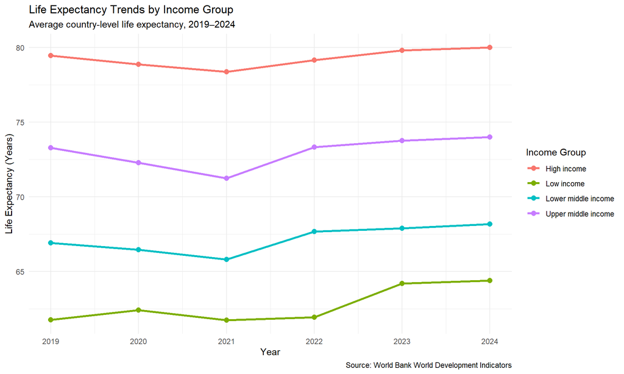

```r
income_trends <- life_clean %>%
  group_by(IncomeGroup, Year) %>%
  summarise(
    AverageLifeExpectancy = mean(
      LifeExpectancy,
      na.rm = TRUE
    ),
    .groups = "drop"
  )

ggplot(
  income_trends,
  aes(
    x = Year,
    y = AverageLifeExpectancy,
    color = IncomeGroup,
    group = IncomeGroup
  )
) +
  geom_line(linewidth = 1.2) +
  geom_point(size = 2.5) +
  scale_x_continuous(breaks = 2019:2024) +
  labs(
    title = "Life Expectancy Trends by Income Group",
    subtitle = "Average country-level life expectancy, 2019–2024",
    x = "Year",
    y = "Life Expectancy (Years)",
    color = "Income Group",
    caption = "Source: World Bank World Development Indicators"
  ) +
  theme_minimal()
```

This visualization compares average life expectancy across different income groups from 2019 to 2024. It helps show how life expectancy changed during and after the COVID-19 pandemic and whether recovery patterns differed between income groups. The chart also highlights the differences in life expectancy levels across these groups. Each average represents the countries and economies with available data, rather than a population-weighted global average.

## Largest Life Expectancy Declines

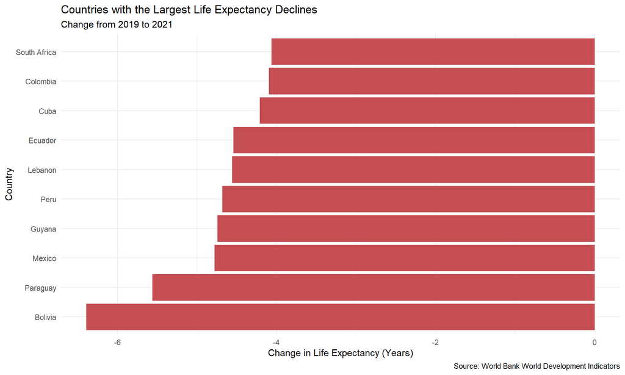

```r
largest_declines <- life_changes %>%
  filter(!is.na(PandemicChange)) %>%
  slice_min(
    PandemicChange,
    n = 10,
    with_ties = FALSE
  )

ggplot(
  largest_declines,
  aes(
    x = reorder(`Country Name`, PandemicChange),
    y = PandemicChange
  )
) +
  geom_col(fill = "#C44E52") +
  coord_flip() +
  labs(
    title = "Countries with the Largest Life Expectancy Declines",
    subtitle = "Change from 2019 to 2021",
    x = "Country",
    y = "Change in Life Expectancy (Years)",
    caption = "Source: World Bank World Development Indicators"
  ) +
  theme_minimal()
```

This visualization shows the 10 countries with the largest life expectancy declines between 2019 and 2021. Bolivia experienced the largest decline at approximately 6.39 years, followed by Paraguay at 5.56 years and Mexico at 4.78 years. Several Latin American countries appear in this chart, showing how strongly life expectancy was affected in parts of the region during the pandemic period.

## Strongest Life Expectancy Recoveries

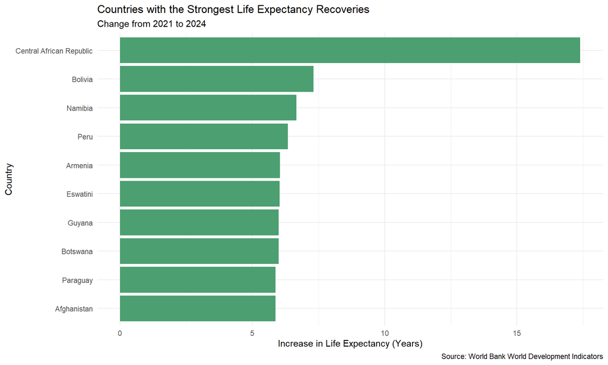

```r
strongest_recoveries <- life_changes %>%
  filter(!is.na(RecoveryChange)) %>%
  slice_max(
    RecoveryChange,
    n = 10,
    with_ties = FALSE
  )

ggplot(
  strongest_recoveries,
  aes(
    x = reorder(`Country Name`, RecoveryChange),
    y = RecoveryChange
  )
) +
  geom_col(fill = "#4C9F70") +
  coord_flip() +
  labs(
    title = "Countries with the Strongest Life Expectancy Recoveries",
    subtitle = "Change from 2021 to 2024",
    x = "Country",
    y = "Increase in Life Expectancy (Years)",
    caption = "Source: World Bank World Development Indicators"
  ) +
  theme_minimal()
```

This visualization shows the countries with the largest increases in life expectancy between 2021 and 2024. The Central African Republic had the largest reported increase at 17.4 years, but its data contain unusual fluctuations that require verification. Bolivia followed with an increase of 7.31 years, Namibia with 6.67 years, and Peru with 6.34 years. The results show that countries recovered at different rates, and a strong recovery did not always mean returning to pre-pandemic levels.

## Data Quality Check: Central African Republic

The Central African Republic has unusually large changes in life expectancy between consecutive years. I reviewed these observations separately because they may influence the ranking of countries with the strongest recoveries.

```r
life_clean %>%
  filter(`Country Code` == "CAF") %>%
  arrange(Year) %>%
  select(Year, LifeExpectancy) %>%
  kable(
    digits = 2,
    caption = "Central African Republic Life Expectancy, 2019–2024"
  )
```

Central African Republic Life Expectancy, 2019–2024

| Year | LifeExpectancy |
| --- | --- |
| 2019 | 31.53 |
| 2020 | 50.60 |
| 2021 | 40.28 |
| 2022 | 18.82 |
| 2023 | 57.41 |
| 2024 | 57.67 |

These unusually large changes, especially the decrease in 2022 followed by a sharp increase in 2023, suggest that this country’s results should be interpreted cautiously until the source data can be verified.

## Interactive World Life Expectancy Recovery Map

This interactive map shows how life expectancy changed across countries between 2019 and 2024 compared with their 2019 levels. Use the year slider to explore changes over time.

```r
map_data <- life_clean %>%
  group_by(`Country Code`) %>%
  mutate(
    Life2019 = LifeExpectancy[match(2019, Year)],
    ChangeFrom2019 = LifeExpectancy - Life2019
  ) %>%
  ungroup() %>%
  filter(
    !is.na(ChangeFrom2019),
    !is.na(LifeExpectancy)
  ) %>%
  mutate(
    HoverText = paste0(
      "<b>", `Country Name`, "</b>",
      "<br>Year: ", Year,
      "<br>Life Expectancy: ",
      round(LifeExpectancy, 2), " years",
      "<br>Change from 2019: ",
      sprintf("%+.2f", ChangeFrom2019), " years"
    )
  )

plot_ly(
  data = map_data,
  type = "choropleth",
  locations = ~`Country Code`,
  locationmode = "ISO-3",
  z = ~ChangeFrom2019,
  frame = ~Year,
  text = ~HoverText,
  hoverinfo = "text",
  colorscale = list(
    c(0, "#C44E52"),
    c(0.5, "#F7F7F7"),
    c(1, "#4C9F70")
  ),
  zmin = -10,
  zmax = 10,
  zmid = 0,
  colorbar = list(title = "Change (Years)")
) %>%
  layout(
    title = "Global Life Expectancy Change Since 2019",
    geo = list(
      showframe = FALSE,
      showcoastlines = TRUE,
      projection = list(type = "natural earth")
    )
  ) %>%
  animation_opts(
    frame = 1000,
    transition = 500,
    redraw = TRUE
  ) %>%
  animation_slider(
    currentvalue = list(prefix = "Year: ")
  )
```

[interactive chart not shown]

The interactive map uses red to represent countries with lower life expectancy than in 2019 and green for countries with higher life expectancy. Viewers can move the year slider to compare different years and hover over countries to see their values. Countries without available data or a matching map location may not be colored.

# Results and Discussion

## Countries Still Below Their 2019 Levels

Although many countries experienced increases in life expectancy after 2021, some had not returned to their 2019 levels by 2024. West Bank and Gaza showed the largest overall decline at approximately 6.60 years, followed by Libya and Greenland. This shows that recovery was not equal across countries.

# Conclusion

This project analyzed life expectancy across 217 countries and economies from 2019 to 2024 using World Bank data. The results show that many countries experienced declines during the pandemic period and recovered afterward, but not at the same rate. By cleaning, transforming, and visualizing the data in R, I was able to identify differences in life expectancy recovery across countries and income groups.